# Lb 8 Clustering

Roupen Khanjian

2/27/2021

# Intro to cluster analysis (k-means, hierarchical)

## part 1 K-MEANS CLUSTERING:

Using `palmerpenguins` dataset

#### EDA

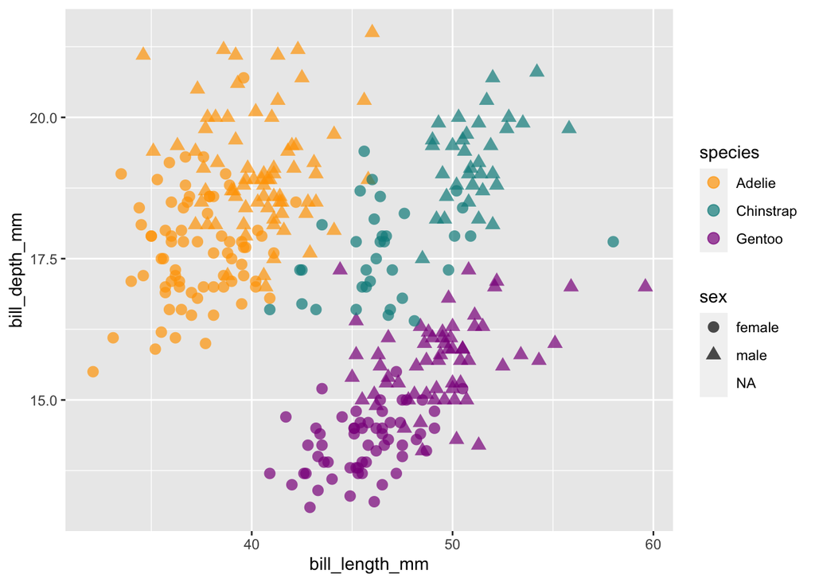

```r
# Bill length versus depth exploratory plot:
ggplot(data = penguins) +
  geom_point(aes(x = bill_length_mm,
                 y = bill_depth_mm,
                 color = species,
                 shape = sex),
             alpha = 0.7,
             size = 3) +
  scale_color_manual(values = c("orange", "cyan4", "darkmagenta"))
```

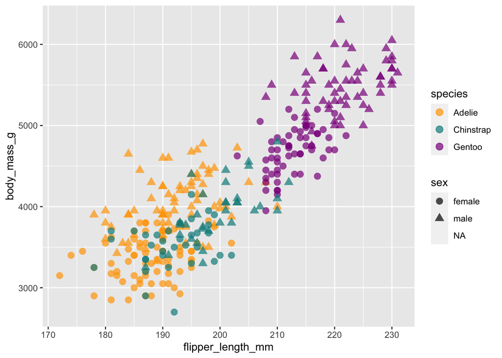

```r
# Flipper length versus body mass exploratory plot:
ggplot(penguins) +
  geom_point(aes(x = flipper_length_mm,
                 y = body_mass_g,
                 color = species,
                 shape = sex),
             size = 3,
             alpha = 0.7) +
  scale_color_manual(values = c("orange","cyan4","darkmagenta"))
```

### pick number of clusters

Using the function `NBClust`, which can specify the distance measure, the min and max # of clusters you want, and the cluistering methods.

Using the 4 columns of the penguins dataset that are numeric, continious variables.

```r
number_est <- NbClust(data = penguins[3:6],
                      min.nc = 2,
                      max.nc = 10,
                      method = "kmeans")
```

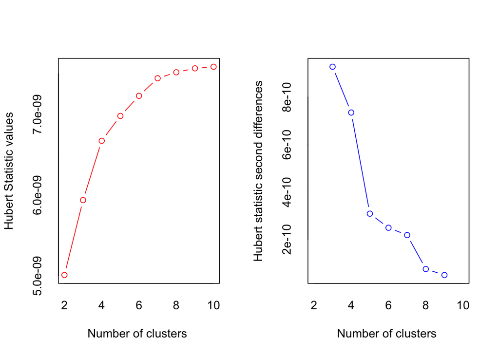

```
## *** : The Hubert index is a graphical method of determining the number of clusters.
##                 In the plot of Hubert index, we seek a significant knee that corresponds to a
##                 significant increase of the value of the measure i.e the significant peak in Hubert
##                 index second differences plot.
##
```

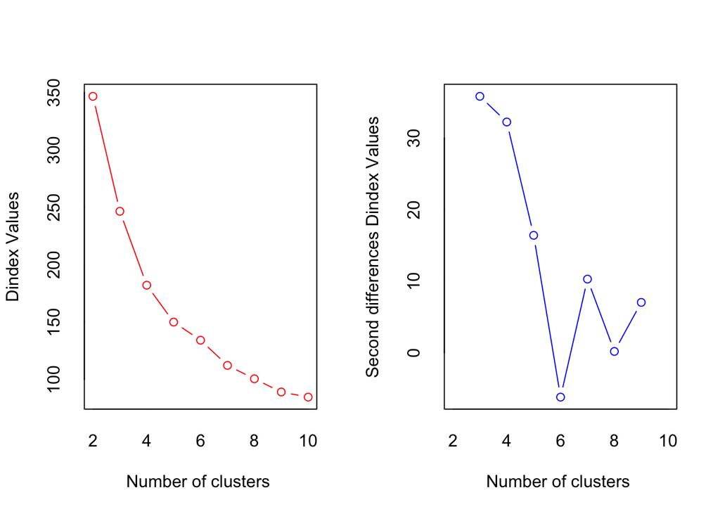

```
## *** : The D index is a graphical method of determining the number of clusters.
##                 In the plot of D index, we seek a significant knee (the significant peak in Dindex
##                 second differences plot) that corresponds to a significant increase of the value of
##                 the measure.
##
## * Among all indices:
## * 8 proposed 2 as the best number of clusters
## * 4 proposed 3 as the best number of clusters
## * 3 proposed 4 as the best number of clusters
## * 1 proposed 5 as the best number of clusters
## * 2 proposed 7 as the best number of clusters
## * 5 proposed 9 as the best number of clusters
## * 1 proposed 10 as the best number of clusters
##
##                    ***** Conclusion *****
##
## * According to the majority rule, the best number of clusters is  2
##
##
```

```r
number_est
```

```
## $All.index
##          KL        CH Hartigan     CCC    Scott      Marriot       TrCovW
## 2    4.2442  930.7898 339.4007 60.3272 2863.489 1.505108e+19 8.503304e+14
## 3    1.7929 1096.4356 265.3223 -2.4916 3062.067 1.894886e+19 2.133802e+14
## 4    2.2121 1387.3852 163.0813  2.7050 3290.894 1.725364e+19 6.675599e+13
## 5    2.1473 1578.6734  98.2372  5.6827 3467.347 1.609268e+19 3.049327e+13
## 6    0.7109 1645.8407 149.0231  6.8679 3546.690 1.837535e+19 1.826896e+13
## 7    2.9447 1998.7092  69.3253 10.6394 3680.641 1.690555e+19 8.748022e+12
## 8    0.9685 2071.4083  74.6940 11.4832 3760.053 1.750533e+19 5.980878e+12
## 9  169.1328 2220.4848  18.3320 12.8762 3836.441 1.772039e+19 3.969998e+12
## 10   0.0048 2078.1993  97.9884 11.7599 3852.547 2.087061e+19 3.567812e+12
##      TraceW Friedman     Rubin Cindex     DB Silhouette   Duda Pseudot2   Beale
## 2  58696922 1669.851  106.8518 0.2399 0.6007     0.6296 0.7282  99.2775  0.8967
## 3  29374348 1776.351  213.5153 0.2360 0.6215     0.5650 0.5865 134.6784  1.6912
## 4  16477803 1990.021  380.6256 0.2028 0.6223     0.5531 1.1740 -22.2279 -0.3542
## 5  11114958 2142.536  564.2733 0.1883 0.6176     0.5335 0.5051  54.8755  2.3165
## 6   8606206 2302.842  728.7618 0.2397 0.6495     0.5190 1.0559  -7.1435 -0.1262
## 7   5961953 2612.371 1051.9830 0.2089 0.6230     0.5351 1.0273  -2.8458 -0.0633
## 8   4939722 2866.156 1269.6815 0.1905 0.6191     0.5176 1.1310 -11.1171 -0.2746
## 9   4036925 3238.492 1553.6264 0.1694 0.5938     0.5410 1.1349  -4.7558 -0.2691
## 10  3826284 3288.966 1639.1552 0.1679 0.6021     0.5269 0.5903  22.2076  1.5957
##    Ratkowsky       Ball Ptbiserial    Frey McClain   Dunn Hubert SDindex
## 2     0.4787 29348460.9     0.6992  1.2824  0.2995 0.0139      0  0.0078
## 3     0.4082  9791449.2     0.6451  1.0774  0.4776 0.0179      0  0.0057
## 4     0.3658  4119450.7     0.5836  1.0704  0.6151 0.0210      0  0.0062
## 5     0.3421  2222991.5     0.5358  0.7241  0.7071 0.0240      0  0.0069
## 6     0.3120  1434367.6     0.5229  0.7759  0.7181 0.0335      0  0.0066
## 7     0.2921   851707.6     0.4920  1.7027  0.7397 0.0362      0  0.0081
## 8     0.2742   617465.2     0.4568  0.9652  0.8264 0.0358      0  0.0109
## 9     0.2584   448547.2     0.4333 10.3861  0.8603 0.0360      0  0.0139
## 10    0.2455   382628.4     0.4112  0.4038  0.9593 0.0358      0  0.0229
##      Dindex   SDbw
## 2  346.7122 0.8605
## 3  246.5041 0.7606
## 4  182.1056 0.4503
## 5  149.9349 0.4269
## 6  134.1617 0.3293
## 7  112.1947 0.2043
## 8  100.5131 0.2474
## 9   89.0159 0.2886
```

[output cut: 24 more lines]

```
##                   Frey McClain   Dunn Hubert SDindex Dindex   SDbw
## Number_clusters 4.0000  2.0000 7.0000      0  3.0000      0 7.0000
## Value_Index     1.0704  0.2995 0.0362      0  0.0057      0 0.2043
##
## $Best.partition
##   [1] 1 1 1 1 1 1 2 1 1 1 1 1 1 2 1 1 2 1 1 1 1 1 1 1 1 1 1 1 1 1 1 1 1 1 1 1 1
##  [38] 1 2 1 1 1 2 1 2 1 1 1 1 1 1 1 1 1 1 1 1 1 1 1 2 1 1 1 1 1 1 1 2 1 1 1 1 1
##  [75] 1 1 1 1 1 1 2 1 1 1 1 1 1 1 1 1 1 1 2 1 1 1 1 1 1 1 2 1 1 1 1 1 1 1 2 1 2
## [112] 1 1 1 1 1 1 1 1 1 1 1 1 1 1 1 1 1 1 1 1 1 2 1 1 1 1 1 1 1 1 1 1 1 1 1 1 1
## [149] 1 1 1 2 2 2 2 2 2 2 2 2 2 2 2 2 2 1 2 1 2 2 2 2 2 2 2 2 2 1 2 2 2 2 2 2 2
## [186] 2 2 2 2 1 2 1 2 1 2 2 2 1 2 2 2 2 2 2 2 2 2 1 2 2 2 1 2 2 2 2 2 2 2 2 2 2
## [223] 2 2 2 2 2 2 2 2 2 2 2 2 2 2 2 2 2 2 2 2 2 2 2 2 2 2 2 2 2 2 2 2 2 2 2 2 2
## [260] 2 2 2 2 2 2 2 2 2 2 2 2 2 2 2 1 1 1 1 1 1 1 1 1 1 1 1 1 1 1 1 1 1 1 2 1 1
## [297] 1 1 1 1 1 1 1 2 1 1 1 1 1 1 1 2 1 2 1 1 1 1 1 2 1 1 1 1 1 1 1 1 1 1 1 1 1
## [334] 1 1 1 1 1 1 1 1 1
```

```r
# By these estimators, 2 is identified as the best number of clusters by the largest number of algorithms (8 / 30)...but should that change our mind? Maybe...but here I think it makes sense to still stick with 3 (a cluster for each species) and see how it does.
```

### Create a complete and scaled version of the data.

Going to use 3 clusters, though thee may be a case to choose 2 since Adelie and chinstrap penguins are pretty similar. To do this, we are going to drop any observations where we have a missing value for one of the 4 variables. Sometimes want to impute the missing values instead though.

```r
# drop rows with missing values for the 4 columns
penguins_complete <- penguins %>%
  drop_na(bill_length_mm, bill_depth_mm, body_mass_g, flipper_length_mm)

# only keep numerical columns we are working with, then scale them.
penguins_scale <- penguins_complete %>%
  select(ends_with("mm"), body_mass_g) %>%
  scale()
```

### do k-means

```r
penguins_km <- kmeans(penguins_scale, centers = 3)

# how many observations are assigned to each cluster?
penguins_km$size
```

```
## [1]  87 132 123
```

```r
# what cluster is each obs in penguins_scale assigned to?
penguins_km$cluster
```

```
##   [1] 2 2 2 2 2 2 2 2 1 2 2 2 2 2 2 2 1 2 1 2 2 2 2 2 2 2 2 2 2 2 2 2 2 2 2 2 2
##  [38] 2 2 2 2 2 1 2 2 2 2 2 1 2 2 2 1 2 2 2 2 2 2 2 1 2 2 2 2 2 2 2 1 2 2 2 1 2
##  [75] 1 2 2 2 1 2 1 2 2 2 2 2 2 2 2 2 1 2 2 2 1 2 2 2 1 2 1 2 2 2 2 2 2 2 1 2 1
## [112] 2 1 2 1 2 2 2 2 2 2 2 1 2 2 2 2 2 1 2 1 2 2 2 2 2 2 2 2 2 2 2 2 2 2 2 2 2
## [149] 2 2 1 3 3 3 3 3 3 3 3 3 3 3 3 3 3 3 3 3 3 3 3 3 3 3 3 3 3 3 3 3 3 3 3 3 3
## [186] 3 3 3 3 3 3 3 3 3 3 3 3 3 3 3 3 3 3 3 3 3 3 3 3 3 3 3 3 3 3 3 3 3 3 3 3 3
## [223] 3 3 3 3 3 3 3 3 3 3 3 3 3 3 3 3 3 3 3 3 3 3 3 3 3 3 3 3 3 3 3 3 3 3 3 3 3
## [260] 3 3 3 3 3 3 3 3 3 3 3 3 3 3 3 1 1 1 1 1 1 1 1 1 1 1 1 1 1 1 1 1 1 1 1 2 1
## [297] 2 1 1 1 1 1 1 1 2 1 2 1 1 1 1 1 1 1 1 1 1 1 1 1 1 1 1 1 1 1 1 1 2 1 1 1 1
## [334] 1 1 1 1 1 1 1 1 1
```

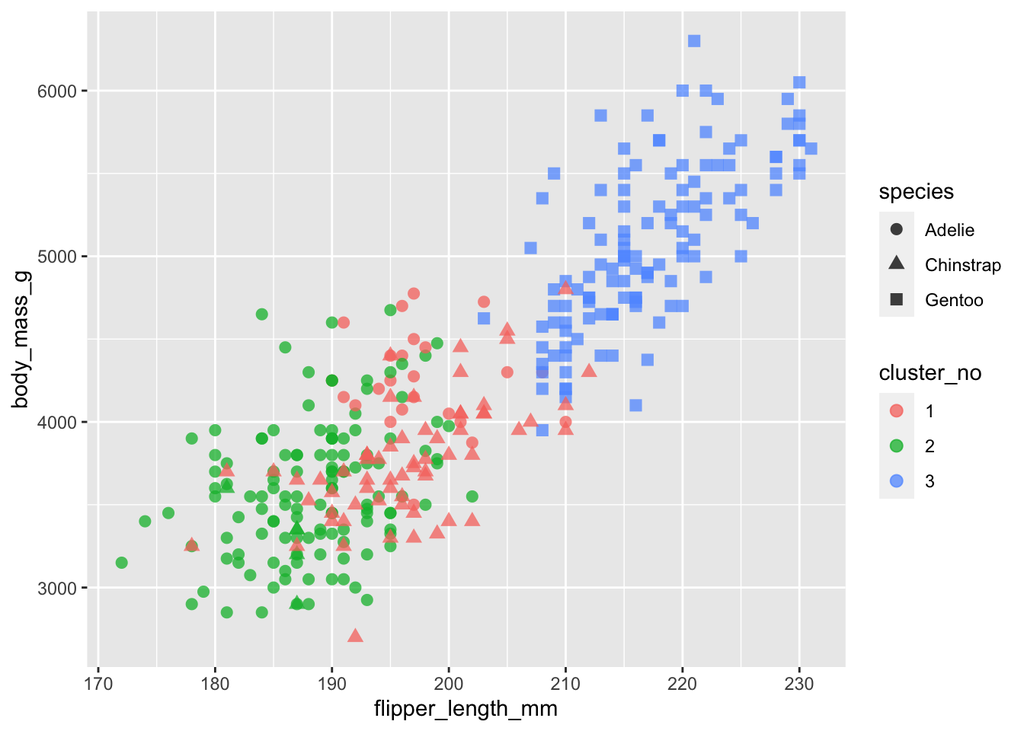

```r
# combine data with cluster number from kmeans and see how it was clustered
penguins_c1 <- data.frame(penguins_complete,
                          cluster_no = factor(penguins_km$cluster))

# plot flipper lngth vs body mass, indicitaing which sluter each penguin is assigned to

ggplot(data = penguins_c1) +
  geom_point(aes(x = flipper_length_mm,
                 y = body_mass_g,
                 color = cluster_no,
                 shape = species),
             size = 2.5,
             alpha = 0.75)
```

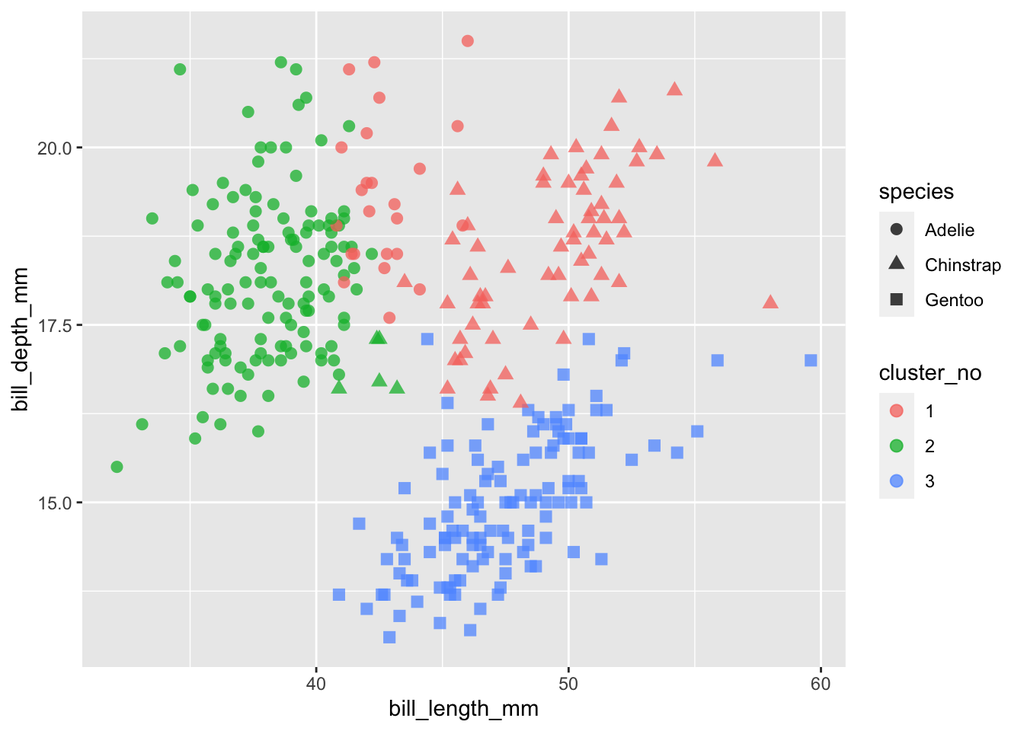

```r
# plot with bill_length_mm vs bill_depth_mm

ggplot(data = penguins_c1) +
  geom_point(aes(x = bill_length_mm,
                 y = bill_depth_mm,
                 color = cluster_no,
                 shape = species),
             size = 2.5,
             alpha = 0.75)
```

```r
# could be the case for 2 clusters, adelie + chinstrap and gentoo since some chinstrap was incorrectly clustered as adelie.
```

```r
penguins_c1 %>%
  count(species, cluster_no) %>%
  pivot_wider(names_from = cluster_no, values_from = n) %>%
  rename(`cluster 1` = 1, `cluster 2` = 2, `cluster 3` = 3)
```

```
## # A tibble: 3 x 4
##   `cluster 1` `cluster 2` `cluster 3`   `3`
##   <fct>             <int>       <int> <int>
## 1 Adelie               24         127    NA
## 2 Chinstrap            63           5    NA
## 3 Gentoo               NA          NA   123
```

Most chinstraps are in cluster 1, most adelie are in cluster 2, AND all the gentoos are in cluster 3. Thus, the k-means clustering does a good job, but can make the case for only 2 clusters. COOL!

## part 2 Hierarchical clustering

use `stats::hclust` function for agglomerative hierarchical clusting using worldbank environmental data from data set in project file.

```r
wb_env <- read_csv("wb_env.csv")
# View(wb_env)

# only keep top 20 greenhouse gas emitters

wb_ghg_20 <- wb_env %>%
  arrange(-ghg) %>%
  head(20)
```

### scale the data

```r
# scale and select the numeric variables
wb_scaled <- wb_ghg_20 %>%
  select(3:7) %>%
  scale()

# update to add rownames (county names) from wb_ghg_20
rownames(wb_scaled) <- wb_ghg_20$name
```

### find euclidean distances

Use `stat::dist()` function to find euc distances in multivarite spce between the different observations

```r
# compute dissimilarty values (euclidean disteances):
euc_distance <- dist(wb_scaled, method = "euclidean")

euc_distance
```

```
##                              China United States    Brazil     India
## United States            3.7956245
## Brazil                   6.0443837     2.8206420
## India                    5.4093362     2.6248888 1.9114804
## Russian Federation       5.9230812     2.8769143 1.2327036 2.7218022
## Japan                    7.0325381     3.5426110 1.6620208 3.1940922
## Germany                  6.8325188     3.3121909 1.5065925 2.0765379
## Australia                6.8524778     3.4270747 1.5503826 1.9645980
## Canada                   7.3060055     3.9332041 1.8293060 3.4438861
## Indonesia                6.8276442     3.4217447 1.0276207 2.2680866
## Mexico                   6.8711055     3.4649821 1.6948329 1.9401437
## Korea, Rep.              7.2491009     3.7460475 1.5873942 3.0677544
## United Kingdom           7.0119978     3.7479265 2.4476479 2.1179322
## France                   6.9757861     3.5390215 1.6892054 2.0664048
## Central African Republic 8.3680604     5.5534823 4.1216586 4.3268980
## Italy                    7.0511516     3.5554098 1.6449455 2.2038733
## Sudan                    7.5704913     4.4979249 2.9678234 2.6682964
## Poland                   7.0479677     3.5685444 1.5696824 2.1991746
## Turkey                   7.0266686     3.5766683 1.6524464 2.1280869
## Thailand                 7.0231771     3.5490127 1.3718412 2.2568935
##                          Russian Federation     Japan   Germany Australia
## United States
## Brazil
## India
## Russian Federation
## Japan                             1.4099493
## Germany                           2.3724425 1.9026072
## Australia                         2.5128244 2.1519017 0.3299147
## Canada                            1.4698230 0.5075464 2.1947094 2.4011546
## Indonesia                         1.5702517 1.1790600 1.0573981 1.1855239
## Mexico                            2.6607604 2.3075896 0.4431582 0.1760967
## Korea, Rep.                       1.6315019 0.4948065 1.5935691 1.8161026
## United Kingdom                    3.4748297 3.1587658 1.2564281 1.0474019
## France                            2.6304532 2.2073985 0.3668077 0.1490621
## Central African Republic          4.0718157 3.7856438 4.3044273 4.4011417
## Italy                             2.5171795 1.9885400 0.2481851 0.3027050
## Sudan                             3.4762567 3.1614618 2.7111390 2.7229387
## Poland                            2.4352723 1.9226954 0.2887252 0.3241977
## Turkey                            2.5663247 2.1067426 0.3322899 0.1961589
## Thailand                          2.1566356 1.6316921 0.4822111 0.5895814
```

[output cut: 45 more lines]

```
## Japan
## Germany
## Australia
## Canada
## Indonesia
## Mexico
## Korea, Rep.
## United Kingdom
## France
## Central African Republic
## Italy
## Sudan                    2.6969773
## Poland                   0.1205012 2.6818766
## Turkey                   0.1595710 2.7061756 0.1904815
## Thailand                 0.4423152 2.6543721 0.3349944 0.5109848
```

Can see that we can manually create the dendogram, but yay R

### perfrom hierarchical clustering by complete linkage with stats::hclust()

`stats::hclust` function performs hierarchical cluserting, given a dissimilarity matrix (matrix of euclidean distances) using a linkage we specifiy

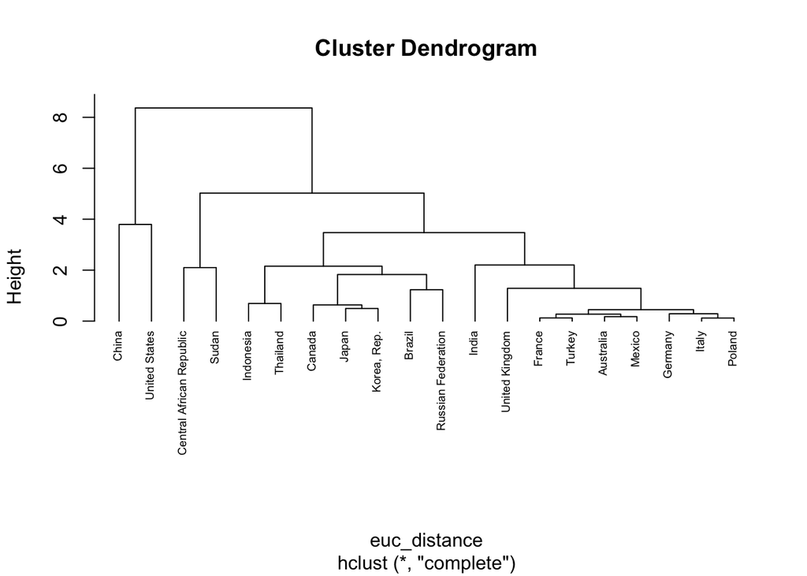

```r
# hierarchical clustering (complete linkage)
hc_complete <- hclust(euc_distance, method = "complete")

#plot
par(mfrow = c(1,1))
plot(hc_complete, cex = 0.6, hang = -1)
```

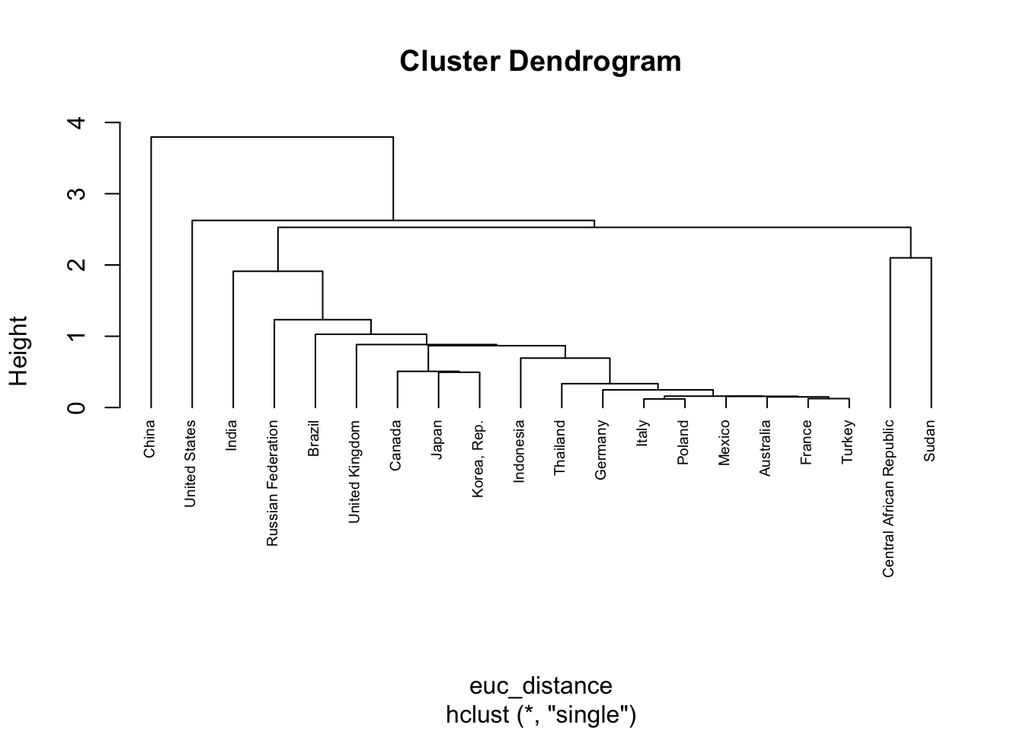

```r
# single linkage
hc_single <- hclust(euc_distance, method = "single")

# plot it
plot(hc_single, cex = 0.6, hang = -1)
```

### make a tanglegram to compare dendrograms

Make a tanglegram to compare clustering by complete and single linkage. use `dendextend::tanglegram`

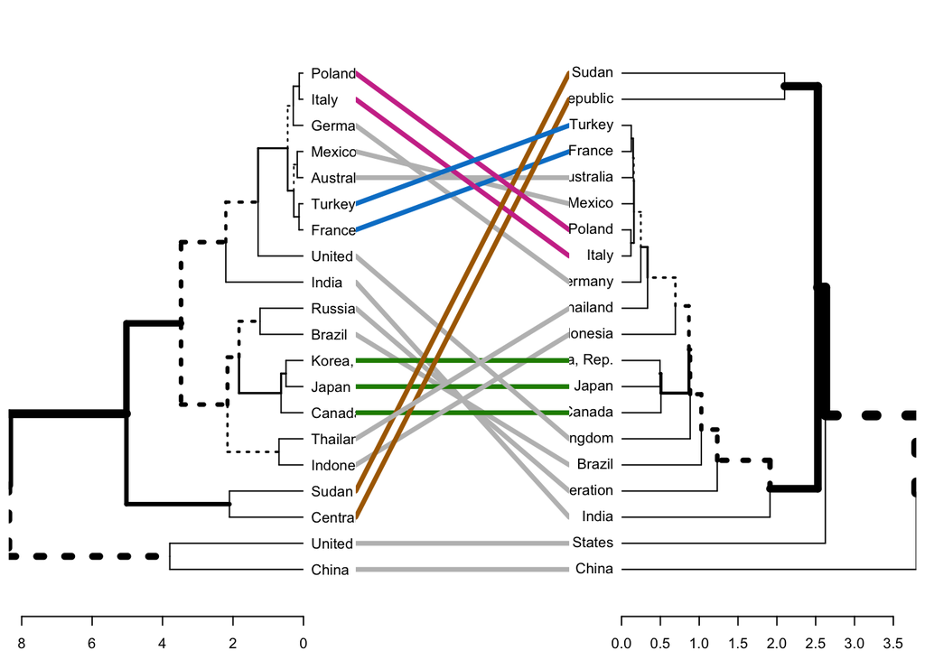

```r
# convert to class dendrogram
dend_complete <- as.dendrogram(hc_complete)
dend_single <- as.dendrogram(hc_single)

tanglegram(dend_complete, dend_single)
```

Can compare how the 2 types of linkages calculate clustering.

### plotting dendrograms in ggplot!

`ggdendrogram`

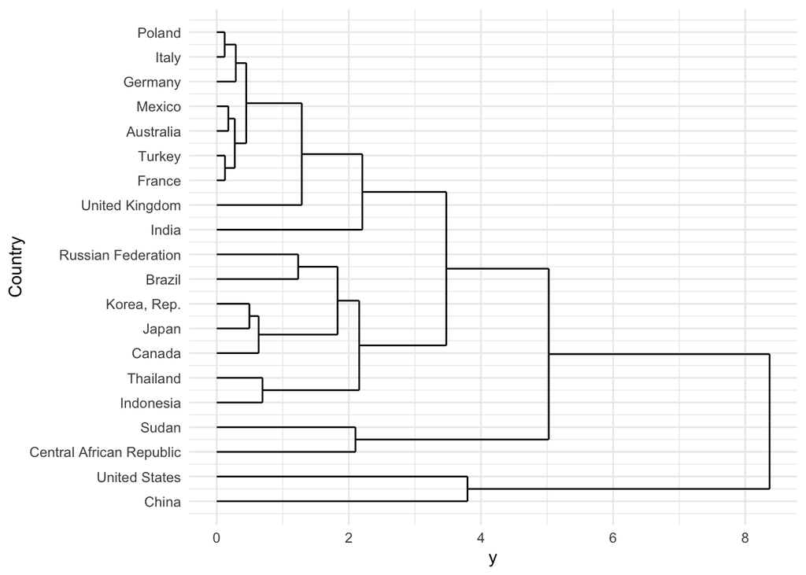

```r
ggdendrogram(data = hc_complete,# from hclust function
             rotate = TRUE) +
  theme_minimal() +
  labs(x = "Country")
```

COOL!